# Assignment 6: Predicting Jumping Jacks with a Gyroscope and Survey using kMeans and PCA

Zach Friedman, StanleySiHeng Zhao, Rong Sang, Ruoyi Zhang, Hyungoo Lee, Yingxin Ye, Yuxuan Ge, Danny Shan

12/5/2020

*Task I*

*You will be working in groups on a quantified student project*

*Download the Sensor Kinetics Pro app to your iOS or Android device (or similar gyroscope measuring app)*

*Split into subgroups with each subgroup investigating one measures available in the app*

*Each subgroup should report back after 20min with what they have learned*

*Task II*

*1. In consultation with your group select a physical activity that: a) can be measured using the app, b) has a concrete, continuous, countable outcome and c) some members of the group are experts and some are novices at. Describe your project:*

**The physical activity we choose was jumping jacks. We measured how many jumping jacks we did in 30 seconds during the Hackathon on December 2nd, 2020. While we did jumping jacks, we held a cell phone in our right hand to record the movement data.**

*2. Collect measurements for all members of the group performing the task using the app*

**In this project, we used the App “Physics Toolbox Sensor Suite”. We used the gyroscope function in the app to record position change while we were performing jumping jacks in 30 seconds.**

*3. Create a Github repo where you can store and share your data*

https://github.com/zjf2003tc/Assignment6_JumpingJacks

## Merging and Cleaning data

#### Below is the data table with all the engineered features of position data. “sum.diff.(x,y,z)” was calculated by taking the sum of the absolute value of the difference between the lead row (one measurement ahead) and the current row. Thus, it represents the total change in gyroscope vectors for each position. The other features are standard statistical measures.

#### It is difficult to definitively interpret the meaning of each variable, but these are some conclusions we reached.

#### Average refers to the average position the phone was in. The average position should be the neutral state which would result in an average of 0. Most people’s position averages were indeed close to 0. However, through testing we observed that slight variations in the positions of one’s wrist throughout the movement could influence the average and we discuss this in greater detail when suggesting interventions.

#### Standard Deviation refers to the average variation from the mean (around 0 for most people), thus the jumping jack recordings with the most extreme peaks and troughs should result in the largest standard deviations. This may be due to a combination of how quickly someone moved their arms, the stability of the phone in one’s hand, the height of someone’s jumps, and the specific form used (more discussion will be offered later).

#### Range was calculated using the max minus the min (the highest peak and the lowest trough) and thus is likely a very similar measure to standard deviation.

#### Sum.diff measures the total change in position throughout the 30 seconds of recording. We think the number of jumping jacks plus the range of rotation result in the largest swings in sum.diff.

| name | sum.diff.x | sum.diff.y | sum.diff.z | average.x | sd.x | average.y | sd.y | average.z | sd.z | range.x | range.y | range.z |
| --- | --- | --- | --- | --- | --- | --- | --- | --- | --- | --- | --- | --- |
| danny | 661.99 | 562.38 | 285.50 | 0.00 | 1.39 | 0.10 | 1.16 | 0.05 | 0.69 | 15.92 | 11.39 | 9.47 |
| friedman | 1572.80 | 1474.81 | 1453.28 | 0.37 | 3.31 | 0.40 | 2.22 | 0.13 | 6.73 | 22.89 | 20.30 | 23.18 |
| ge | 1272.97 | 1508.30 | 1665.09 | 0.50 | 3.27 | 0.17 | 2.67 | -0.13 | 7.20 | 16.62 | 17.86 | 27.17 |
| lee | 1605.95 | 1103.18 | 1405.67 | -0.91 | 4.26 | -0.51 | 2.59 | -0.40 | 8.11 | 26.47 | 18.02 | 30.80 |
| ye | 603.23 | 903.14 | 659.52 | -0.01 | 1.82 | 0.09 | 2.05 | 0.03 | 4.59 | 10.04 | 13.03 | 16.02 |
| zhang | 1843.65 | 1582.72 | 1191.61 | 0.31 | 3.95 | -0.07 | 3.05 | 0.20 | 4.85 | 21.23 | 20.18 | 21.01 |
| zhao | 620.25 | 403.32 | 259.89 | -0.01 | 1.10 | 0.01 | 0.41 | 0.01 | 0.31 | 6.27 | 3.21 | 2.17 |

#### The ten most highly correlated pairs of variables are listed below Standard Deviation, range, and sum of positions seem to be highly correlated in all of the dimensions.

| Var1 | Var2 | Correlation |
| --- | --- | --- |
| sd.z | range.z | 0.972 |
| sum.diff.x | sd.x | 0.951 |
| sum.diff.z | sd.z | 0.942 |
| sum.diff.z | range.z | 0.933 |
| sd.y | range.y | 0.931 |
| sum.diff.y | range.y | 0.923 |
| sum.diff.y | sd.y | 0.914 |
| sd.x | range.z | 0.913 |
| sum.diff.y | sum.diff.z | 0.908 |
| sd.x | sd.y | 0.894 |

#### Standard deviation and sum.diff were dropped from the kmeans model because they seemed to be highly correlated with range. We left range and average of all three dimensions for the KMeans analysis.

## Kmeans Using Position Data

#### Below is a table of individuals sorted by number of jumping jacks performed and their respective clusters. There is no clear relationship between jumping jacks and cluster assignment.

| name | jumping_jacks | fitdd.cluster |
| --- | --- | --- |
| friedman | 54 | 1 |
| danny | 44 | 2 |
| zhao | 41 | 2 |
| ge | 36 | 1 |
| lee | 32 | 1 |
| zhang | 32 | 1 |
| ye | 23 | 2 |

*4. Using K-means, can you identify the novices from the experts using only the app data?*

**We defined experts as having done 40 or more jumping jacks in 30 seconds. The resulting clusters grouped danny, zhao, and ye in one group, although danny and zhao were in the expert category, ye had the fewest jumping jacks. Thus, the clusters do not seem to be able to reliably distinguish the novices from the experts.**

### Cluster visualization

*5. Visualize your results using ggplot2*

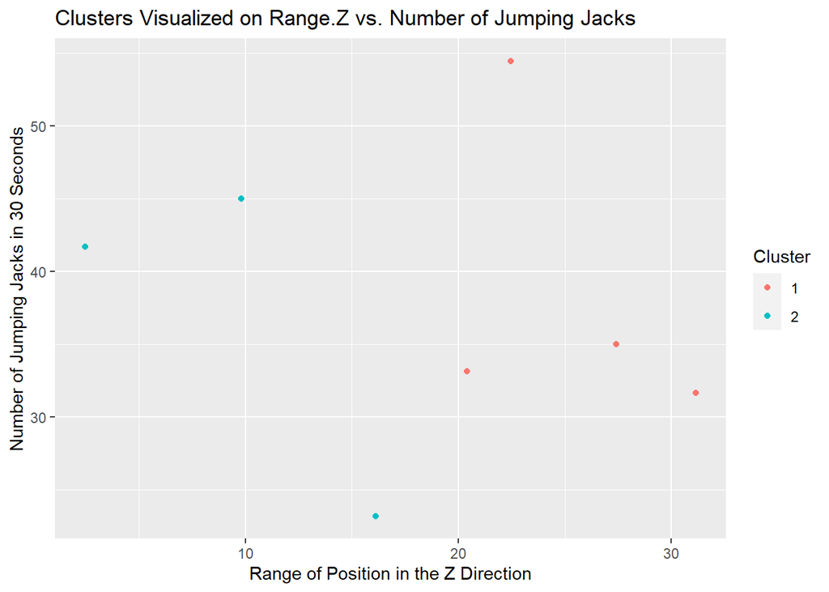

#### Above is a visualization of the relationship between range.z and number of jumping jacks. When replacing range.z with range.x, the graph looked very similar. Clearly, the clusters are a decent indicator of the x-axis, the raw gyroscope data. However, the clusters do not show a clear relationship to the y-axis, the jumping jacks. Thus, this attempt at kMeans failed to provide strong predictive power for jumping jack ability. There are a few potential reasons for this finding:

**(1) The gyrsocope data did not accurately or consistently gauge important aspects of performing jacks quickly. Two of the dimensions, x and z, measured movements that were unrelated to the position of one’s hand during a jumping jack. During a jumping jack, one does not bend their wrist up and down or shake their wrist, as in waving their hand. The y-dimension is an exception and will be discussed later. One other caveat to the unrelatedness of the gyroscope data is that the three vectors do spike in unison when one’s hand quickly accelerates or decelerates, likely because the gyroscope is under so much angular force. So, it is still somewhat surprising that kMeans proved ineffective when using statistical measures of these three variables in the model.**

**(2) The gyroscope data is affected by the orientation in which each group member was holding their phone. Holding the phone upright or flat in their hand could have affected some of the results.**

**(3) There are not enough data to identify experts based on this clustering method; there were only seven participants.**

## PCA: Predicting Using Survey Data

*Task III*

*1. Devise five questions on a five point Likert scale that ask members of your group about their experience with your chosen task. Collect data from all members of your group.*

**We surveyed our group members and asked ourselves various questions related to our experience with jumping jacks and overall physical fitness. These were developed with the aim of differentiating novices and experts in the group.**

**Q1.I consider myself physically fit.**

**Q2.I regularly do jumping jacks.**

**Q3.I eat a nutritious and balanced diet.**

**Q4.I performed at my average ability during the test.**

**Q5.I have good jumping jack technique/form**

*2. Run a PCA analysis on the data*

### PCA on Survey Data

*3. What does PC1 represent in your analysis?*

```
##          PC1       PC2        PC3        PC4        PC5
## Q1 0.5311690 0.4075651 0.04575605 0.08685713 0.73628280
## Q2 0.4521982 0.5655364 0.14585808 0.17534682 0.65089501
## Q3 0.3146002 0.4288572 0.84195963 0.07263543 0.05418734
## Q4 0.3957719 0.5080976 0.45243569 0.60800147 0.10410380
## Q5 0.5077082 0.2682863 0.25107316 0.76600760 0.14300158
```

**Based on the loadings output, it seems like Q1, Q2 and Q5 primarily make up PC1. These questions are related to physical fitness, jumping jack practice, and technique. Thus, in general PC1 is related to jumping jack ability. Self-reported performance and nutrition did not contribute as much to PC1.**

*4. Visualize the PC1 results for each member of your group*

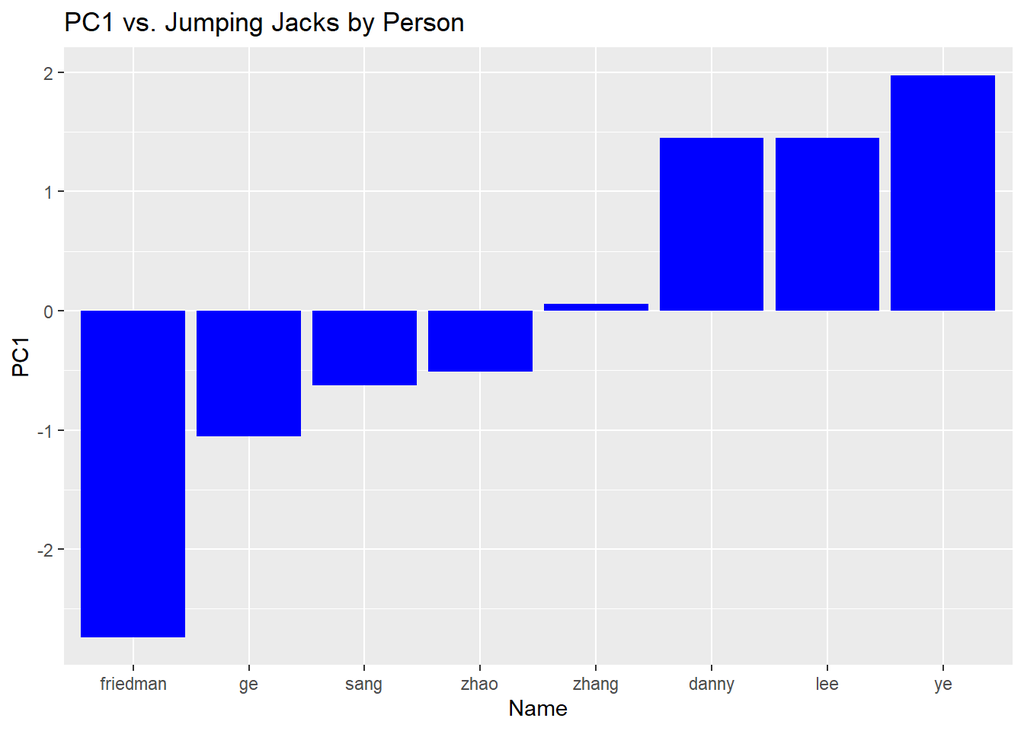

## Conclusions and Prescriptions

### Conclusions

*Task IV*

*1. If you could only choose one thing to predict the score for each member of your group (raw data variable, a cluster or a PC) what would it be and why?*

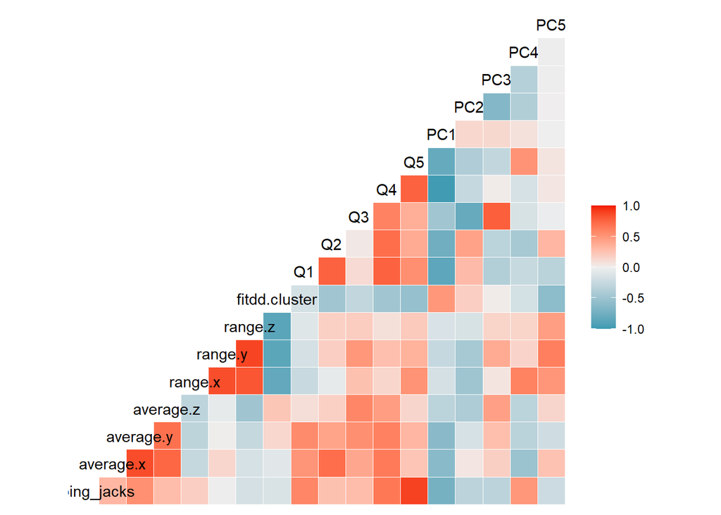

#### The darkness of the bottom row in the graphic indicates the magnitude of the correlation between each of the variables and jumping jack count. The data are shown, sorted numerically in a table, below for easier visualization.

| Variable | Correlation with Jumping Jacks |
| --- | --- |
| Q5 | 0.895 |
| PC1 | -0.723 |
| Q4 | 0.658 |
| Q1 | 0.584 |
| average.y | 0.534 |

#### These 5 variables were most highly correlated with jumping jacks. Notably Q1, Q4, and Q5, were most significant, along with PC1, which was made up primarily of a combination of Q1, Q2, Q4, and Q5.

#### Interestingly through this further investigation, we realized that the y-dimension of the gyroscope data was moderately predictive of jumping jack count. The y-direction involves twisting of the wrist, left to right, with the phone help upright.

#### We hypothesize that this type of wrist movement occurred when participants moved their hands into a clapping position when bringing their hands together. Then, they would hold their palms facing foreward when bringing their arms down, or they even touched their palms to the sides of their body, resulting in further y-movement in either case.

#### Other group members simply touched the tips of their fingers together, with their palms facing foreward, and kept their palms facing foreward as they brought their arms down.

#### Novice Form

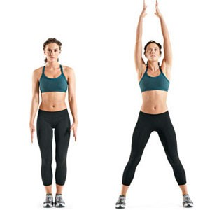

#### Expert Form

[figure not shown]

#### If we had to choose one variable, we would use PC1 because it has the second highest correlation and is incorporates sevearal of the question used from the survey, which was a much better predictor than the gyroscope data.

*2. Create a visualization that supports your conclusion*

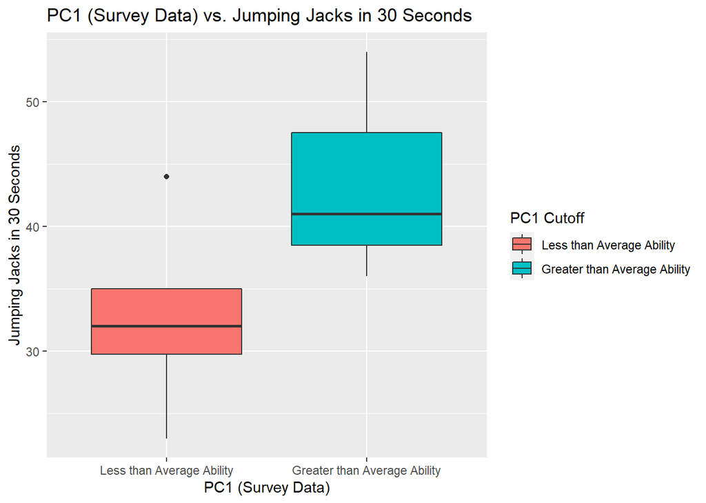

### Prescriptive Analytics

*3. Based on your conclusion devise an intervention that would help novice members of your group improve their performance.*

#### To conclude, we found that the strongest predictors for jumping jack performance in this 30 second test were mostly self-reported survey questions including good jumping jack technique, physcial fitness, and self-relative performance in the moment. The gyroscope data also indicated that twisting of the wrists was associated with performance. This likely occurred while clapping one’s hands at the top of the movement and slapping them on one’s sides at the bottom of the movement.

#### Thus we recommend the following interventions to improve jumping jack speed:

##### 1) Practice jumping jacks more often while focusing on reducing the rotation of your wrists employing the “Expert Form” above. This may help them move into the 40+ jumping jack expert group.

##### 2) Increase physical fitness through consistent cardiovascular exercise.

##### 3) When doing the 30 second test again, be committed to push physical limits and intently focus on the challenge to ensure self-relative performance is at least average, but ideally high. This was this evidenced by the positive correlation between jumping jacks and respondents’ answers to their self-reported performance.